# Introduction to R and Quantitative Methods

Burrel Vann Jr

###### Navigation

- **Intro to R**
- **t-Test** [*t-Test example*]
- **Analysis of Variance (ANOVA)** [*ANOVA example*]
- **Chi Square** [*Chi Square example*]
- **Correlation** [*Correlation example*]
- **Regression** [*Regression example*]

### What is R?

We will be using [R](http://cran.stat.ucla.edu/), an open-source statistical program. Open-source, of course, means that it is free to use. R is a programming language, and the basic R program runs through command-line. To make it easy on first-time users, we will also be using R’s graphical user interface, [RStudio](https://www.rstudio.com/products/rstudio/download2/), that runs R in one of its windows – without you having to open R.

### Downloading R

1. Go to the [**R website**](http://cran.stat.ucla.edu/) to download the program. Under the “Download and Install R” section, select the distribution that matches your computer’s operating system (macOS/OSX, Windows, Linux).
   - For Mac Users: On the next page, under the “Files” section, select the first file/link (which should be something like “R-3.x.x.pkg”)
   - For Windows Users: On the next page, select the link/word “base”. On the following page, select the large link (which should be something like “Download R 3.x.x for Windows”)
   - For Linux Users: On the next page, select your specific distribution, and follow the instructions.
2. For all users, install the downloaded R program.
3. Next, we will download [**RStudio**](https://www.rstudio.com/products/rstudio/download2/) which is a easily understandable user interface for using R. Under “Installers for Supported Platforms” select the RStudio installer that matches your operating system.
4. After the download is complete, install the RStudio program.

### Getting Started with R

Open the RStudio program, which should be linked to R.

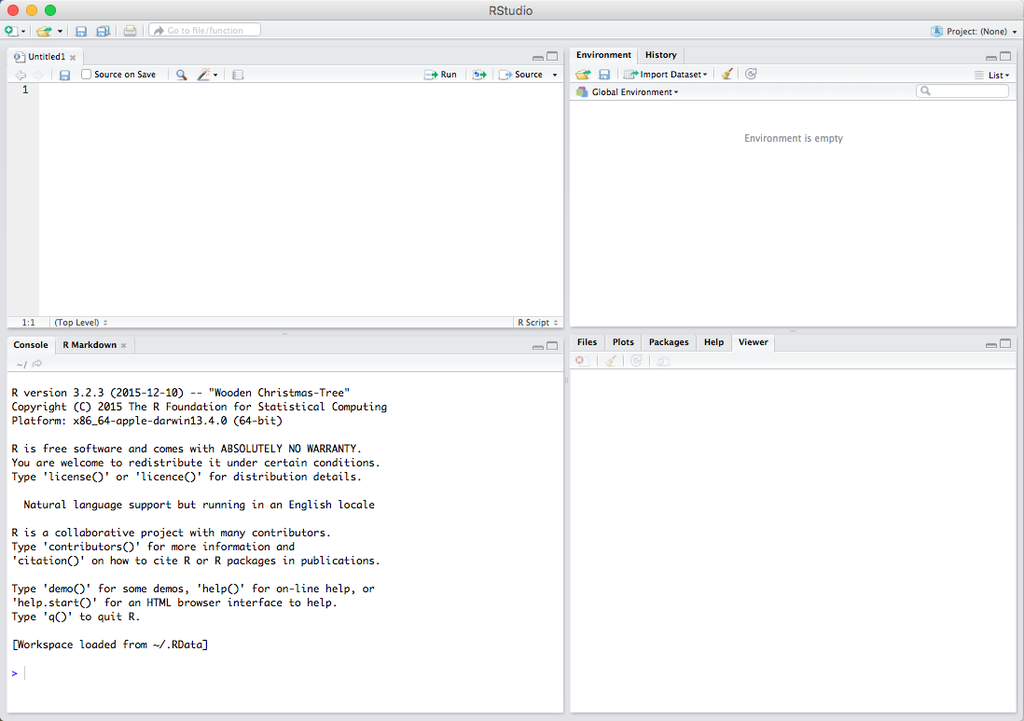

There are various windows within RStudio, including the Script window, where all your codes are viewable:

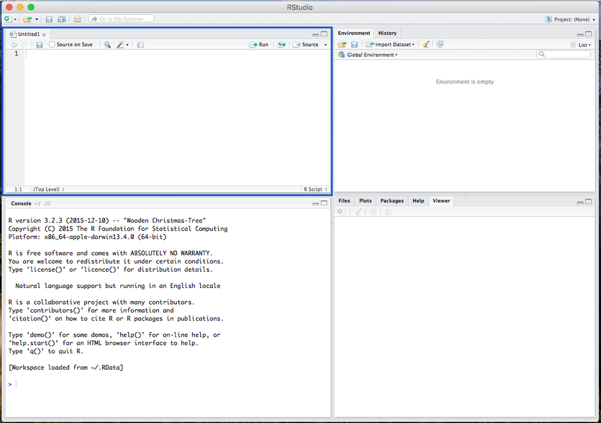

The R console window where you paste and run your code:

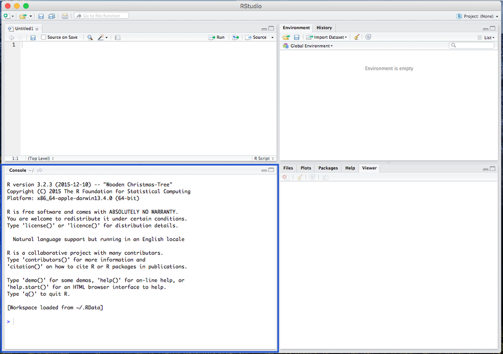

The Environment window, where your data and background processes are viewable:

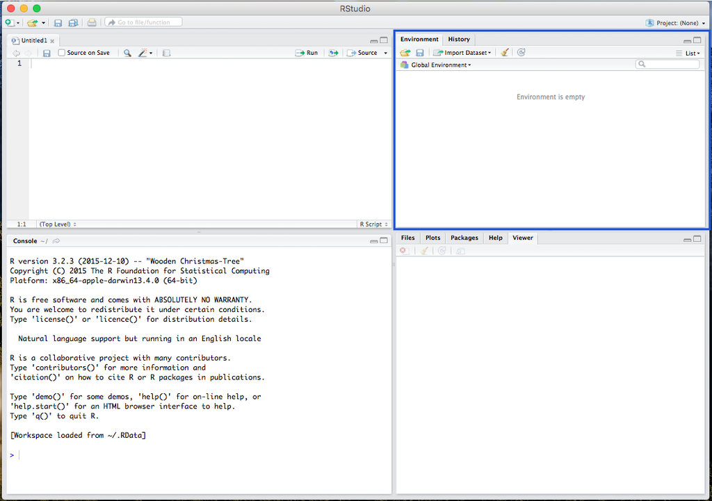

And the Plot/Viewer window, where your output figures/diagrams, help information, and file viewer are located:

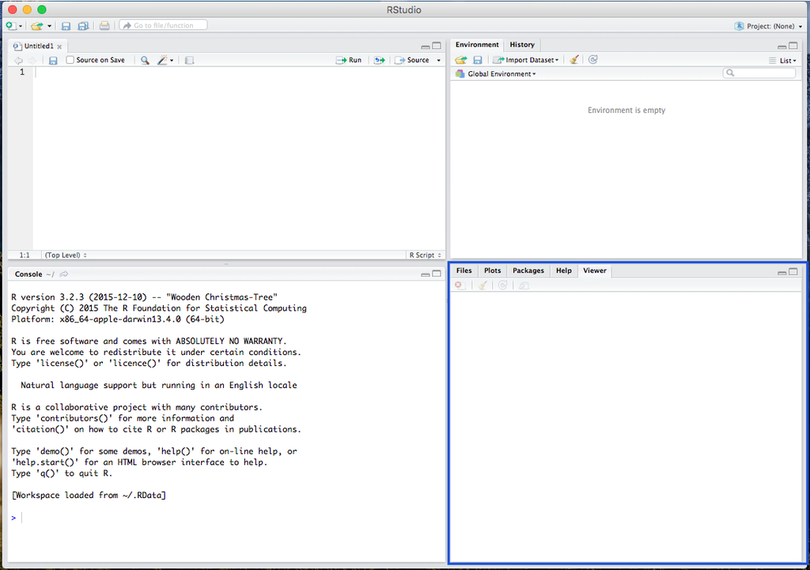

### Getting Familiar with R

#### Setting the Working Directory

Before running analyses, you have to set your working directory. This is the folder where your data/output is and will be saved. For example, I use the following:

```r
setwd("/Users/burrelvannjr/Desktop/PA606")
```

This will be different for you. To set your working directory, use `setwd("directory")`, and replace the word “directory” with the *pathname* of the folder you want to be your directory (or under the **Session** menu, select **Set Working Directory**, then select **Choose Directory** and navigate to your desired folder).

#### Installing Packages and Loading them for Use as Libraries

Because R is and open-source statistical program, many of its functions are built by programmers in the form of **packages** or **libraries**. We will be using four packages in this exercise: the `MASS`, `psych`, `lattice`, and `mosaic` packages.

Install the packages from the repository (copy and paste the lines below)

```
install.packages("MASS")
install.packages("psych")
install.packages("lattice")
install.packages("mosaic")
```

Load the packages as libraries

```r
library(MASS)
library(psych)
library(lattice)
library(mosaic)
```

#### A Note on Commenting

Througout any script, you’ll also notice a line of text with a pound sign (e.g. hashtag) preceding it, like this `#this is a how to calculate a mean`. This is a **comment**, which is just a note to yourself. Comments remind the user what the a bit of code is supposed to do.

### Working with Data

#### Calculations

In R/RStudio, we can use the Script (and Console) window to make calculations. For example, we can run the following…

```r
3 + 2
```

```
## [1] 5
```

#### The Assignment Operator for Creating Objects

The great thing about R is that, because it is an object-oriented programming language, you can assign **object names** to any calculation or data set. This creates a working copy of the calculation (or data set) in R’s memory that you can run operations on. To do so, you simply must assign an object name using a *left arrow* (the assignment operator) like this: `new_object <- dataset`. For example, we could run…

```r
x <- 3 + 2
```

… and then run…

```r
x
```

```
## [1] 5
```

… which gives us the same result, but now we can run manipulations on the new object (or variable) **x**.

#### Creating a List as an Object

Sometimes, for quick analyses, you may need to read in a list of numbers (in your working Environment). To read in a list, you use the concatenate `c` function. You can create a list by replacing the word “LIST” from this with the actual list: `c(LIST)`.

To create an object out of a list of numbers, we could do the following…

```r
list <- c(1, 6, 3, 2, 7, 4, 6, 9)
```

Now that `list` is a useable object, we can run manipulations and univariate statistics on it (described below).

In addition, you can use the `c` or concatenate function to manually input **columns** of data (variables) and merge them into one data frame.

Let’s say someone sent you the following image:

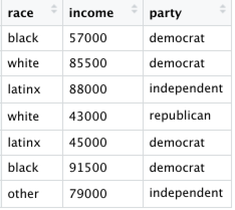

We could insert the data, one variable at a time, each as a new list object:

```r
race <- c("black","white","latinx","white","latinx","black","other")
income <- c(57000,85500,88000,43000,45000,91500,79000)
party <- c("democrat","democrat","independent","republican","democrat","democrat","independent")
```

Next, we can view the lists by calling the object names:

```r
race
```

```
## [1] "black"  "white"  "latinx" "white"  "latinx" "black"  "other"
```

```r
income
```

```
## [1] 57000 85500 88000 43000 45000 91500 79000
```

```r
party
```

```
## [1] "democrat"    "democrat"    "independent" "republican"  "democrat"
## [6] "democrat"    "independent"
```

To merge these objects together, we use the `cbind` (or column bind) function – which converts the list into a column (variable). However, the best or more appropriate way is to merge objects into a data frame, using the `data.frame` function.

```r
data <- data.frame(race,income,party)
```

And the data should now be presented as a data frame:

```r
data
```

```
##     race income       party
## 1  black  57000    democrat
## 2  white  85500    democrat
## 3 latinx  88000 independent
## 4  white  43000  republican
## 5 latinx  45000    democrat
## 6  black  91500    democrat
## 7  other  79000 independent
```

#### Removing Objects from your Environment

Many times, we’ll be working with several objects, and ultimately decide that some of them are no longer needed. In this case, we would want to tidy up our environment by removing an object. To do so, we must use the `rm` function. You can do it like this, changing the word “OBJECT” to the name of the object that you’re trying to remove from the R environment: `rm(OBJECT)`.

```r
rm(x)
```

#### Reading in CSV Data Sets

Many data sets that researchers work with come in the form of a **CSV** file. A CSV (Comma Separated Values) file is just a Microsoft Excel spreadsheet (with rows as observations and columns as variables), that is converted into CSV format.

A CSV file must be “read” into the R environment for you to use it. To do so, you’ll have to call in the CSV file (data set) with one of R’s functions: the `read.csv` function. Additionally, you will have to give the CSV a new object name (using the assignment operator **<-**), so we can place it in our working environment. You can do it like this, changing the word “PATHNAME” to the pathname to the csv file you’re reading into the R environment: `data1 <- read.csv("PATHNAME.csv", header=TRUE, sep=",")`.

#### Working with Stock Data Sets in R

Fortunately, nearly every package in R comes with a data set that R users can use. *To see which stock data sets are installed in your version of R, use the* `data()` *function.* The `MASS` package, for example, comes with a great data set on car manufacturers called `mtcars`. To use this `mtcars` data set, you must call it. Calling the data will load it into your console window. To call a stock data set, just type in the name of the data set (*Note: The data set you’re calling must come from a package that is already LOADED into your R session*). Because the `MASS` package is already loaded, we can call our `mtcars` data set as such…

```r
mtcars
```

```
##                      mpg cyl  disp  hp drat    wt  qsec vs am gear carb
## Mazda RX4           21.0   6 160.0 110 3.90 2.620 16.46  0  1    4    4
## Mazda RX4 Wag       21.0   6 160.0 110 3.90 2.875 17.02  0  1    4    4
## Datsun 710          22.8   4 108.0  93 3.85 2.320 18.61  1  1    4    1
## Hornet 4 Drive      21.4   6 258.0 110 3.08 3.215 19.44  1  0    3    1
## Hornet Sportabout   18.7   8 360.0 175 3.15 3.440 17.02  0  0    3    2
## Valiant             18.1   6 225.0 105 2.76 3.460 20.22  1  0    3    1
## Duster 360          14.3   8 360.0 245 3.21 3.570 15.84  0  0    3    4
## Merc 240D           24.4   4 146.7  62 3.69 3.190 20.00  1  0    4    2
## Merc 230            22.8   4 140.8  95 3.92 3.150 22.90  1  0    4    2
## Merc 280            19.2   6 167.6 123 3.92 3.440 18.30  1  0    4    4
## Merc 280C           17.8   6 167.6 123 3.92 3.440 18.90  1  0    4    4
## Merc 450SE          16.4   8 275.8 180 3.07 4.070 17.40  0  0    3    3
## Merc 450SL          17.3   8 275.8 180 3.07 3.730 17.60  0  0    3    3
## Merc 450SLC         15.2   8 275.8 180 3.07 3.780 18.00  0  0    3    3
## Cadillac Fleetwood  10.4   8 472.0 205 2.93 5.250 17.98  0  0    3    4
## Lincoln Continental 10.4   8 460.0 215 3.00 5.424 17.82  0  0    3    4
## Chrysler Imperial   14.7   8 440.0 230 3.23 5.345 17.42  0  0    3    4
## Fiat 128            32.4   4  78.7  66 4.08 2.200 19.47  1  1    4    1
## Honda Civic         30.4   4  75.7  52 4.93 1.615 18.52  1  1    4    2
## Toyota Corolla      33.9   4  71.1  65 4.22 1.835 19.90  1  1    4    1
## Toyota Corona       21.5   4 120.1  97 3.70 2.465 20.01  1  0    3    1
## Dodge Challenger    15.5   8 318.0 150 2.76 3.520 16.87  0  0    3    2
## AMC Javelin         15.2   8 304.0 150 3.15 3.435 17.30  0  0    3    2
## Camaro Z28          13.3   8 350.0 245 3.73 3.840 15.41  0  0    3    4
## Pontiac Firebird    19.2   8 400.0 175 3.08 3.845 17.05  0  0    3    2
## Fiat X1-9           27.3   4  79.0  66 4.08 1.935 18.90  1  1    4    1
## Porsche 914-2       26.0   4 120.3  91 4.43 2.140 16.70  0  1    5    2
## Lotus Europa        30.4   4  95.1 113 3.77 1.513 16.90  1  1    5    2
## Ford Pantera L      15.8   8 351.0 264 4.22 3.170 14.50  0  1    5    4
## Ferrari Dino        19.7   6 145.0 175 3.62 2.770 15.50  0  1    5    6
## Maserati Bora       15.0   8 301.0 335 3.54 3.570 14.60  0  1    5    8
## Volvo 142E          21.4   4 121.0 109 4.11 2.780 18.60  1  1    4    2
```

While this is great, and the dataset is loaded into your console window, you will need a local copy to run operations on. To create a local copy (an object) so that you can run manipulations on the `mtcars` data, you should create a new object, like this:

```r
data1 <- mtcars
```

Like above, you can now call `data1`, and it will load the same data set into your console window (not shown here). In addition, in RStudio, after you give the data a new name (converting it to a usable object), you can view the data in your upper-right **Environment** window.

#### Calling information for a Variable

To call a specific *variable* or column within the data set, you simply use the dollar sign operator `$`, in the form of `data$variable`. To call the `mpg` variable from the new `data1` data set, we use the following.

```r
data1$mpg
```

```
##  [1] 21.0 21.0 22.8 21.4 18.7 18.1 14.3 24.4 22.8 19.2 17.8 16.4 17.3 15.2
## [15] 10.4 10.4 14.7 32.4 30.4 33.9 21.5 15.5 15.2 13.3 19.2 27.3 26.0 30.4
## [29] 15.8 19.7 15.0 21.4
```

### Univariate Statistics

There are various ways to call a number of univariate statistics in R. As social scientists, the main univariate statistics we are concerned with are the mean, median, standard deviation, minimum, maximum, and range. The stock R program comes with the `summary` function, which, unfortunately, does not provide the *some* measures. Therefore, we use the `describe` function from the `psych` package. We can call univariate statistics for both the full data set and a specific variable.

For the full data set, we can call univariate statistics as such…

```r
describe(data1)
```

```
##      vars  n   mean     sd median trimmed    mad   min    max  range  skew
## mpg     1 32  20.09   6.03  19.20   19.70   5.41 10.40  33.90  23.50  0.61
## cyl     2 32   6.19   1.79   6.00    6.23   2.97  4.00   8.00   4.00 -0.17
## disp    3 32 230.72 123.94 196.30  222.52 140.48 71.10 472.00 400.90  0.38
## hp      4 32 146.69  68.56 123.00  141.19  77.10 52.00 335.00 283.00  0.73
## drat    5 32   3.60   0.53   3.70    3.58   0.70  2.76   4.93   2.17  0.27
## wt      6 32   3.22   0.98   3.33    3.15   0.77  1.51   5.42   3.91  0.42
## qsec    7 32  17.85   1.79  17.71   17.83   1.42 14.50  22.90   8.40  0.37
## vs      8 32   0.44   0.50   0.00    0.42   0.00  0.00   1.00   1.00  0.24
## am      9 32   0.41   0.50   0.00    0.38   0.00  0.00   1.00   1.00  0.36
## gear   10 32   3.69   0.74   4.00    3.62   1.48  3.00   5.00   2.00  0.53
## carb   11 32   2.81   1.62   2.00    2.65   1.48  1.00   8.00   7.00  1.05
##      kurtosis    se
## mpg     -0.37  1.07
## cyl     -1.76  0.32
## disp    -1.21 21.91
## hp      -0.14 12.12
## drat    -0.71  0.09
## wt      -0.02  0.17
## qsec     0.34  0.32
## vs      -2.00  0.09
## am      -1.92  0.09
## gear    -1.07  0.13
## carb     1.26  0.29
```

Whereas, for a specific variable, we can call univariate statistics as such…

```r
describe(data1$mpg)
```

```
##    vars  n  mean   sd median trimmed  mad  min  max range skew kurtosis
## X1    1 32 20.09 6.03   19.2    19.7 5.41 10.4 33.9  23.5 0.61    -0.37
##      se
## X1 1.07
```

In addition, we can call univariate statistics for a variable but broken out by groups/categories of another variable. Note, this is the first step towards bivarate statistics (looking at the relationship between two variables). We do this by using the `describeBy` function, where we list the main variable first, and the grouping/category variable second… as such…

```r
describeBy(data1$mpg, data1$cyl)
```

```
##
##  Descriptive statistics by group
## group: 4
##    vars  n  mean   sd median trimmed  mad  min  max range skew kurtosis
## X1    1 11 26.66 4.51     26   26.44 6.52 21.4 33.9  12.5 0.26    -1.65
##      se
## X1 1.36
## --------------------------------------------------------
## group: 6
##    vars n  mean   sd median trimmed  mad  min  max range  skew kurtosis
## X1    1 7 19.74 1.45   19.7   19.74 1.93 17.8 21.4   3.6 -0.16    -1.91
##      se
## X1 0.55
## --------------------------------------------------------
## group: 8
##    vars  n mean   sd median trimmed  mad  min  max range  skew kurtosis
## X1    1 14 15.1 2.56   15.2   15.15 1.56 10.4 19.2   8.8 -0.36    -0.57
##      se
## X1 0.68
```

Above, we can see that the mean miles per gallon differs by the number of cylinders in a car (e.g. cars with lower cylinders have, on average, higher miles per gallon).

#### A Note on Skewness and Kurtosis

**Skewness** is the measure of how close or far a distribution is from symmetry (the normal curve). It measures the clustering of scores along the X-axis, with regard to the position of the mode, median, and mean. **Kurtosis** is a measure of the *peakedness* of the distribution - how high or low the distribution is on the Y-axis, and how different it is from mesokurtic (e.g. middle kurtosis, or the normal curve).

Skewness ranges from $-\infty$ to $\infty$. The sign indicates the type of skew, with $-$ indicating negative skewness, $+$ indicating positive skewness, and 0 indicating *no* skew… (AKA symmetry, AKA the normal curve). The cutoffs for skewness are as follows:

High: $\geq |1|$

Moderate: $|1| \geq x \geq |.5|$

Low: $|.5| \geq x \geq |0|$

Statisticians have developed a kurtosis measure that represents *excess* kurtosis beyond the normal curve (*although typical kurtosis ranges from 1 to $+ \infty$*). This measure ranges from $-2$ to $+ \infty$. Using this metric, we know that, generally, negative values represent platykurtic distributions and positive values indicate leptokurtic distributions. Distributions close to a kurtosis value of 0 are considered mesokurtic. We use cutoffs to indicate types of kurtosis, as follows…

Platykurtic: $0 \geq x \geq -2$

Mesokurtic: $1 \geq x \geq 0$

Leptokurtic: $+ \infty \geq x \geq 1$

#### Calling Specific Univariate Statistics

Beyond using the `describe` function, you can call singular desired univariate statistics. Here, we’ll ask for a specific univariate statistic, one at a time, for the `mpg` variable.

Below, we’ve added the option for `, na.rm=T` (alternatively, `, na.rm=TRUE`), meaning that if data or observations are missing/NA for the variables we’re working with, we still want R to calculate the statistic for the non-missing cases by removing those missing cases (NAs), select TRUE.

```r
mean(data1$mpg, na.rm=T)
```

```
## [1] 20.09062
```

```r
median(data1$mpg, na.rm=T)
```

```
## [1] 19.2
```

```r
sd(data1$mpg, na.rm=T)
```

```
## [1] 6.026948
```

```r
min(data1$mpg, na.rm=T)
```

```
## [1] 10.4
```

```r
max(data1$mpg, na.rm=T)
```

```
## [1] 33.9
```

```r
range(data1$mpg, na.rm=T)
```

```
## [1] 10.4 33.9
```

### Assessing Normality by Using Visualizations

#### Histograms

In addition, you can create a visual representation (plot) of univariate data using a histogram. For quickly plotting the histogram of one variable, we can use R’s stock `hist` function, as such…

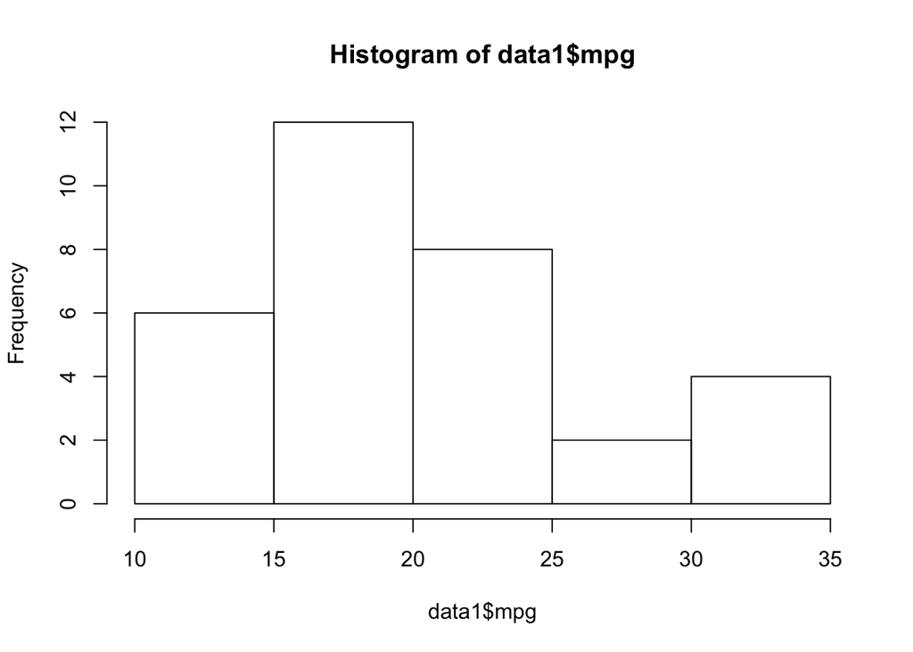

```r
hist(data1$mpg)
```

However, as we begin to move into analyzing bivariate relationships, we may find it necessary to visualize histograms by overlaying normal curves (to demonstrate normality) or to break out the histogram by levels or categories of different variables (to demonstrate within group normality). As such, we should rely on the `histogram` function from the `lattice` package to plot a histogram.

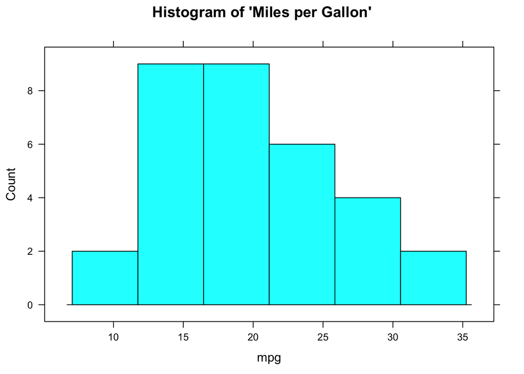

```r
histogram(~ mpg, data = data1, main = "Histogram of 'Miles per Gallon'", type = "count")
```

This should look *similar* to the plot produced by the `hist` function, but it differs in that we can do much more… such as plotting the histogram with a normal curve overlaid, including the placement of the mean.

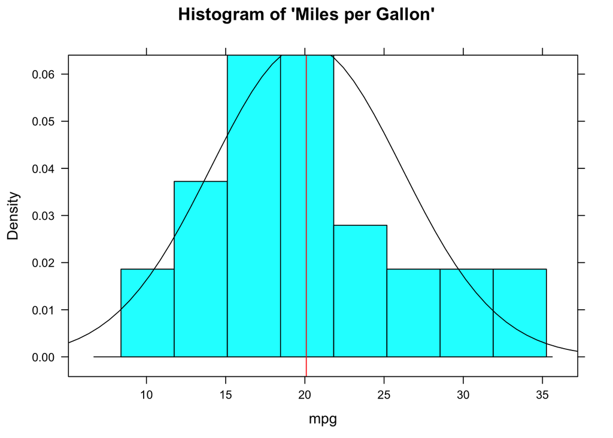

```r
histogram(~ mpg, data = data1, main = "Histogram of 'Miles per Gallon'",
          type = "density",
          panel=function(x, ...) {
            panel.histogram(x, ...)
            panel.abline(v=mean(x, na.rm = TRUE),col="red")
            panel.mathdensity(dmath=dnorm, col="black",
                              args=list(mean=mean(x, na.rm = TRUE),
                                        sd=sd(x, na.rm = TRUE)), ...)
          })
```

Or plotting the histogram for mpg broken out by cylinders… However, because the cylinder variable isn’t *technically* measured as a grouping (nominal or ordinal) variable, we have to tell R to *treat* it as a grouping variable by using the `factor` function. (This is a good habit to start, however.)

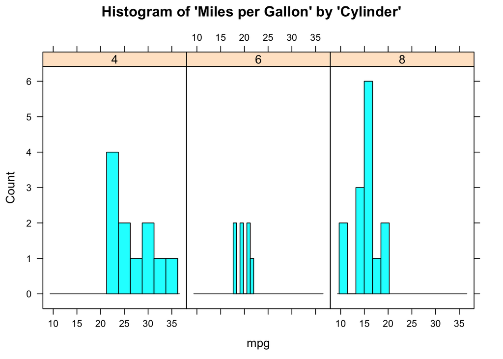

```r
histogram(~ mpg | factor(cyl), data = data1, type = "count", main = "Histogram of 'Miles per Gallon' by 'Cylinder'")
```

#### Boxplots (Box-and-Whisker Plots)

Boxplots also provide a visual representation of the normality of a distribution. The boxplot has a box, a line through the box, two whiskers on either end of the box, and sometimes dots/points outside the whiskers. Below, we get a sense of what each part of the boxplot represents…

- Bottom (or left end) of the **whisker** represents the minimum score for that variable’s distribution
- Bottom (or left end) of the **box** represents the first quartile (the 25th percentile case)
- Middle line (or dot) inside the **box** represents the median, also known as the second quartile (the 50th percentile case)
- Top (or right end) of the **box** represents the third quartile (the 75th percentile case)
- Top (or right end) of the **whisker** represents the maximum score for that variable’s distribution
- Outside dots represent outliers - extreme high or extreme low values for that variable.

To tell if a variable is normally-distributed using the box-and-whisker plot, generally, we want to see that there is *some* distance between the box and the end of the whiskers, that the box isn’t pushed too close to either whisker, that the median line (dot) is near the center of the box, and that there aren’t many outliers (dots) on the outside of the whiskers.

To plot a boxplot, we use the following… (notice that when you’re plotting one variable, the plot is displayed horizontally).

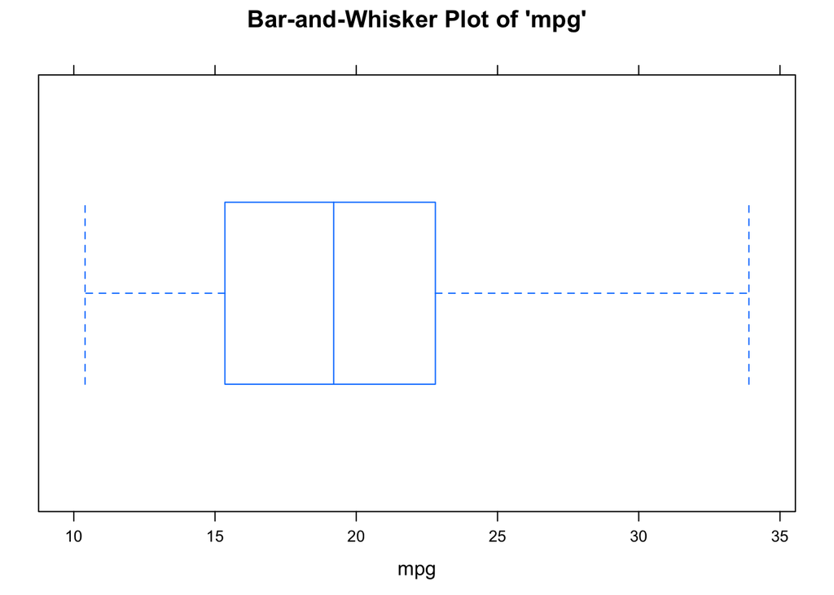

```r
bwplot(~mpg, data = data1, pch="|", main = "Bar-and-Whisker Plot of 'mpg'")
```

Further, to break this distribution out by **Cylinder** (making Cylinder a factor variable), we can do the following…

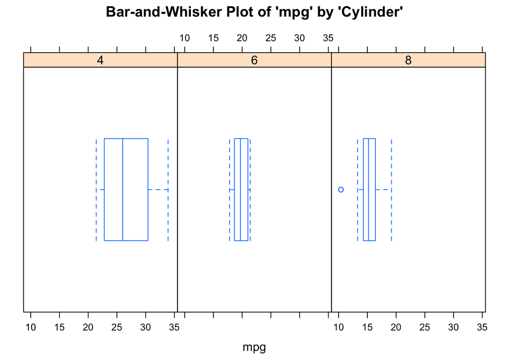

```r
bwplot(~mpg | factor(cyl), data = data1, pch="|", main = "Bar-and-Whisker Plot of 'mpg' by 'Cylinder'")
```

#### Normal Q-Q (Quantile-Quantile) Plots

Much as in the above, we want to assess whether or not our variable follows the normal distribution. As such, the quantile-quantile plot is a visual tool to help us figure out if the empirical distribution of our variable fits (or rather, comes from) a theoretical normal distribution.

We fit a plot of our data/variable (usually on the Y-axis) against theoretical data that should occur if the data came from a normal distribution. If our data actually fit a normal curve, then the dots on the plot should follow a straight line, or be reasonably close to the line plotted.

Below, we can assess normality to determine whether our variable follows a normal distribution, as such…

[figure not shown]

```r
xqqmath(~mpg, data=data1, fitline = TRUE, main = "Normal Q-Q Plot of 'Wr.Hnd'", xlab = "Expected Normal")
```

Additionally, we can break this plot out by another grouping variable.

[figure not shown]

```r
xqqmath(~mpg | factor(cyl), data=data1, fitline = TRUE, main = "Normal Q-Q Plot of 'Wr.Hnd' by 'Cylinder'", xlab = "Expected Normal")
```

### Working with Random, Normally-Distributed Data

R also has a number of functions that work to create random data. To create random, normally-distributed data, use the `rnorm` function, which takes a maximum of three arguments. It should look something like this `rnorm(100,0,1)`, where the first number (here, `100`) represents the number of cases or data points you want in your random normally-distributed data. The second argument/number (here `0`) is the mean that you want your data to have. The third number/argument (here `1`) is the standard deviation that you want your data to have.

Note that the `rnorm` function takes a maximum of three arguments – and it takes a minimum of one argument (the number of cases/data points). The default settings for the `rnorm` function is mean of 0 and a standard deviation of 1. This means that `rnorm(100)` and `rnorm(100,0,1)` will output similar means and standard deviations. Similar, not the exact same, because these data are *randomly* generated, so the values of the data points will vary a bunch but still have a mean of 0 and standard deviation of 1.

```r
rnorm(100,0,1)
rnorm(100)
```

Obviously, you can alter the number of cases involved.

```r
rnorm(10)
```

```
##  [1]  0.3626716 -0.2375895  1.5875182  1.0503585 -0.3376259 -1.8292780
##  [7]  1.4026004 -0.4075904 -1.8497637  0.2354372
```

or…

```r
rnorm(100)
```

```
##   [1] -0.90989538 -0.44804130 -1.52092848 -0.51174399  0.38777545
##   [6]  0.82835194 -0.47357521  0.52780779 -0.28373185  0.91023144
##  [11]  2.32707535  0.06412173  0.79963432 -0.08930429  0.32112013
##  [16] -0.12125396 -0.93647022  0.14304163 -1.21700459 -1.24571555
##  [21]  1.03022148 -1.27887836  0.10091102 -1.73617419  1.09085756
##  [26] -0.57237784  1.00482019 -0.77908627 -0.35402666 -1.44224195
##  [31]  0.27265678 -1.70739609  1.38074707 -1.11307371  0.11710530
##  [36]  0.58271434  1.65136099 -2.04533469 -0.43195395  0.93163102
##  [41] -0.15202549  1.08184048  0.06964323 -2.46044433  0.91395171
##  [46] -1.11016777 -0.19808821 -0.19831070 -1.74104678 -0.07324742
##  [51]  1.97536799  0.83851963  0.14604988 -0.35744339 -0.23594148
##  [56] -0.43568683 -1.29696380 -0.22972101 -0.63631429 -0.04144451
##  [61] -0.24344916  0.99863855  1.04276164 -0.15575822  0.04736486
##  [66] -0.02495770  0.25177464  1.02832048 -0.18359836  0.61836600
##  [71]  1.11183543  1.17433745  1.45512979  0.61718012  0.41696190
##  [76] -0.51407458  0.12044937  0.92419071 -0.63817238 -0.63264605
##  [81]  0.51288832  0.22192473  1.12380966 -0.09582201  0.27132093
##  [86] -2.43005162  0.02320512 -0.35004610 -0.44423663  0.94599732
##  [91]  0.15122282 -1.85229466 -1.88423653  0.39055782  1.17790161
##  [96]  1.22447841  0.42221115  0.44643537  0.08888348  0.36527988
```

or even…

```r
rnorm(1000)
```

(output supressed)

You can also use the assignment operator `<-` to assign the values of the `rnorm` function to an object:

```r
ten<-rnorm(10)
hundred<-rnorm(100)
thousand<-rnorm(1000)
```

Then you can run univariate statistics on those data, and even create a histogram for the data:

```r
mean(thousand)
```

```
## [1] 0.02076514
```

```r
median(thousand)
```

```
## [1] 0.05585287
```

```r
sd(thousand)
```

```
## [1] 0.9710962
```

```r
min(thousand)
```

```
## [1] -3.083616
```

```r
max(thousand)
```

```
## [1] 3.251981
```

```r
range<-max(thousand)-min(thousand)
range
```

```
## [1] 6.335597
```

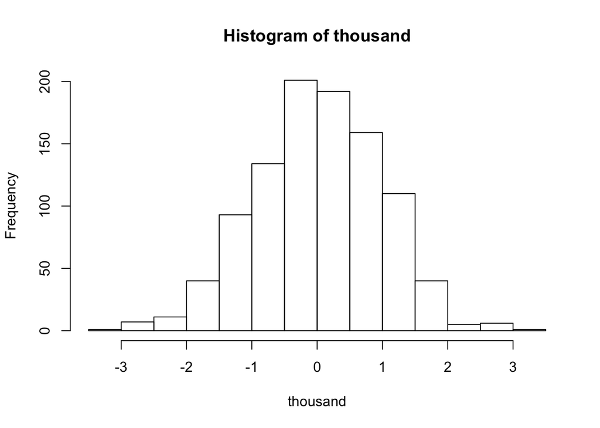

```r
hist(thousand)
```

Finally, you can see how histograms differ when all you do is alter the number of cases:

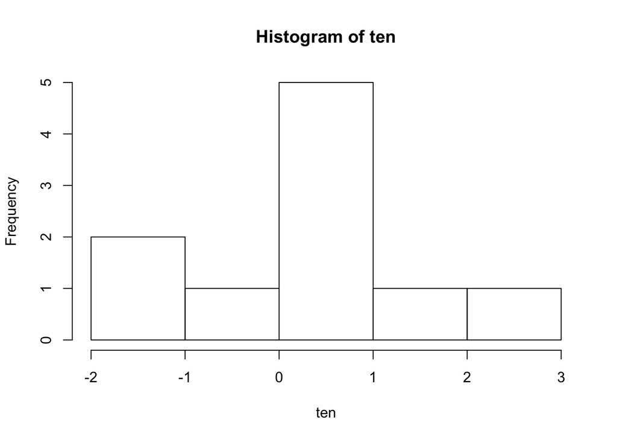

```r
hist(ten)
```

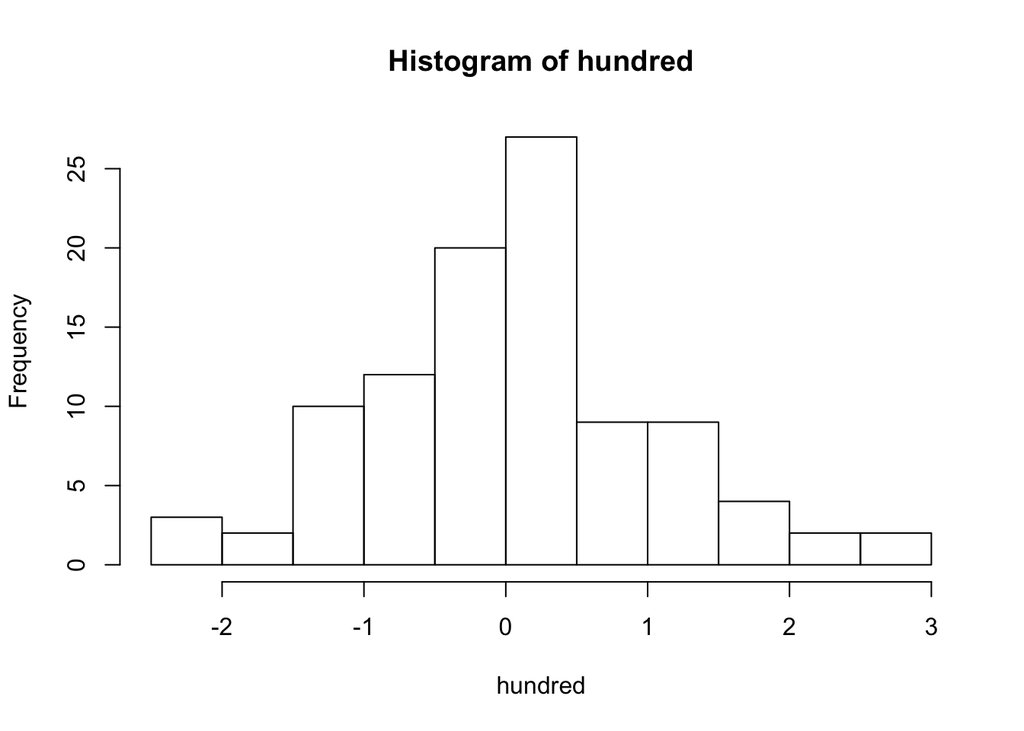

```r
hist(hundred)
```

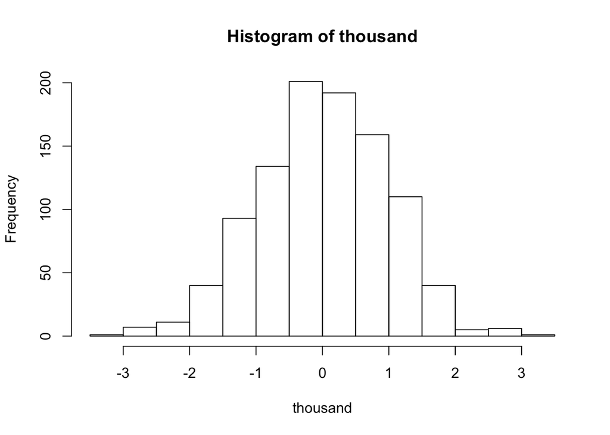

```r
hist(thousand)
```

So now you know that the more cases/data points you have, the more your data will mimic the normal distribution (bell curve).

### R for Data Science

For anyone interested in learning R from the ground, up, for data science, a great resource is [R for Data Science](https://r4ds.had.co.nz/index.html)